# Data Handling: Import, Cleaning and Visualisation

17/09/2020

## Welcome to Data Handling: I.C.V. 2020!

- Fire up your notebooks!
- Go to this page: http://bit.ly/datahandling-2020
- Use one row to respond to the questions in the column headers (see the first two rows for examples).

## Introductory Example

## Data input, processing, output

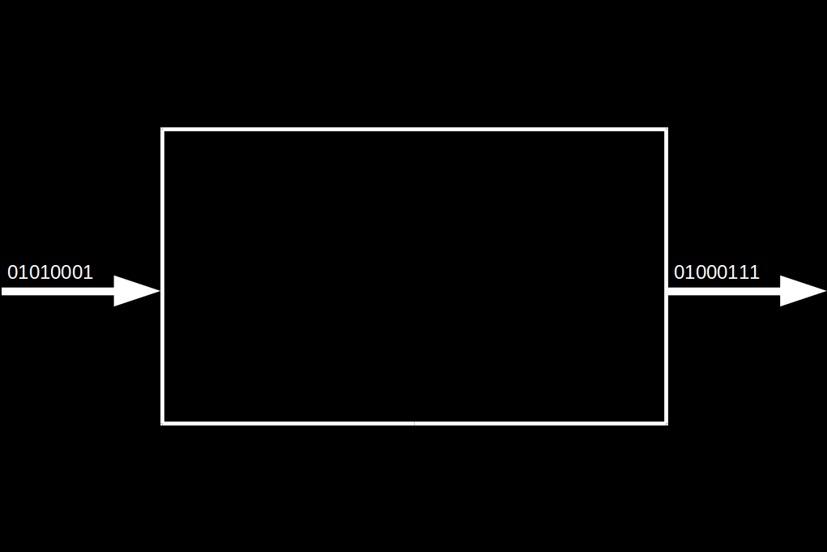

## The Data Pipeline

What could be the *output* of all this?

## The Data Pipeline

- Research report/paper (e.g., BA Thesis)
- Presentation/Slides
- Website
- Web application (interactive; alas the introductory example)
- Dashboard for management
- Recommender system (i.e., a trained machine learning algorithm)
- …

## ‘Data Science’?

## ‘Data Science’?

*“This coupling of scientific discovery and practice involves the collection, management, processing, analysis, visualization, and interpretation of vast amounts of heterogeneous data associated with a diverse array of scientific, translational, and inter-disciplinary applications.”*

University of Michigan ‘Data Science Initiative’, 2015

## But, what about statistics?!

*“Seemingly, statistics is being marginalized here; the implicit message is that statistics is a part of what goes on in data science but not a very big part. At the same time, many of the concrete descriptions of what the DSI will actually do will seem to statisticians to be bread-and-butter statistics. Statistics is apparently the word that dare not speak its name in connection with such an initiative!”*

David Donoho (2015). **50 years of Data Science**

## Background

## What’s new about all this?

*“All in all, I have come to feel that my central interest is in data analysis, which I take to include, among other things: …”*

## What’s new about all this?

*“All in all, I have come to feel that my central interest is in data analysis, which I take to include, among other things: procedures for analyzing data, techniques for interpreting the results of such procedures, ways of planning the gathering of data to make its analysis easier, more precise or more accurate, and all the machinery and results of (mathematical) statistics which apply to analyzing data.”*

## What’s new about all this?

John Tukey (*The Future of Data Analysis*, 1962!)

## Technological change

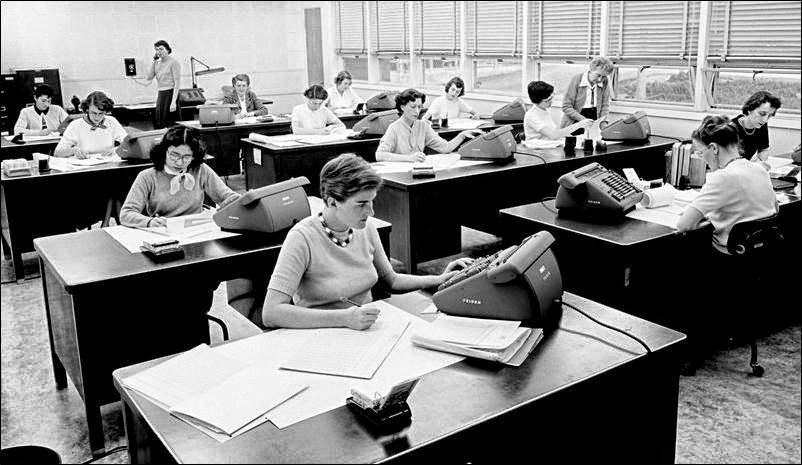

## Technological change

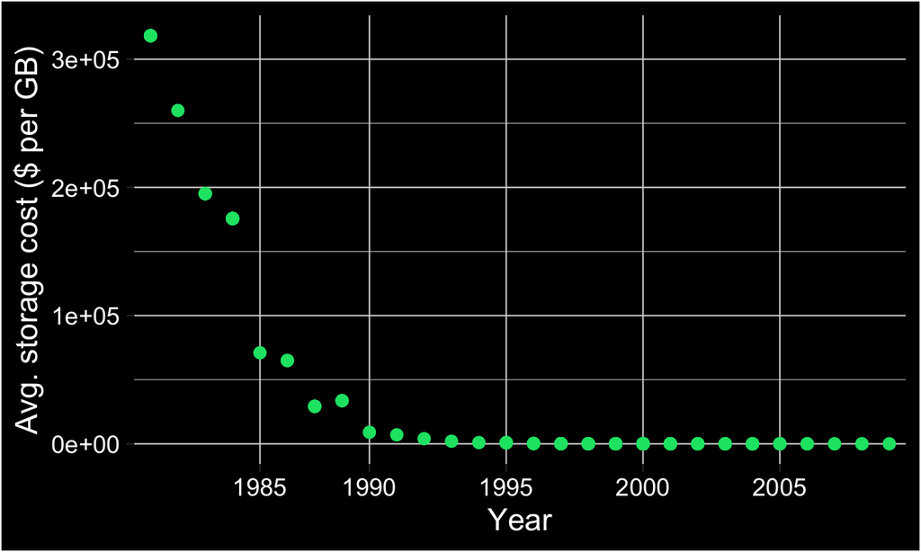

Data source: http://www.mkomo.com/cost-per-gigabyte

## Technological change

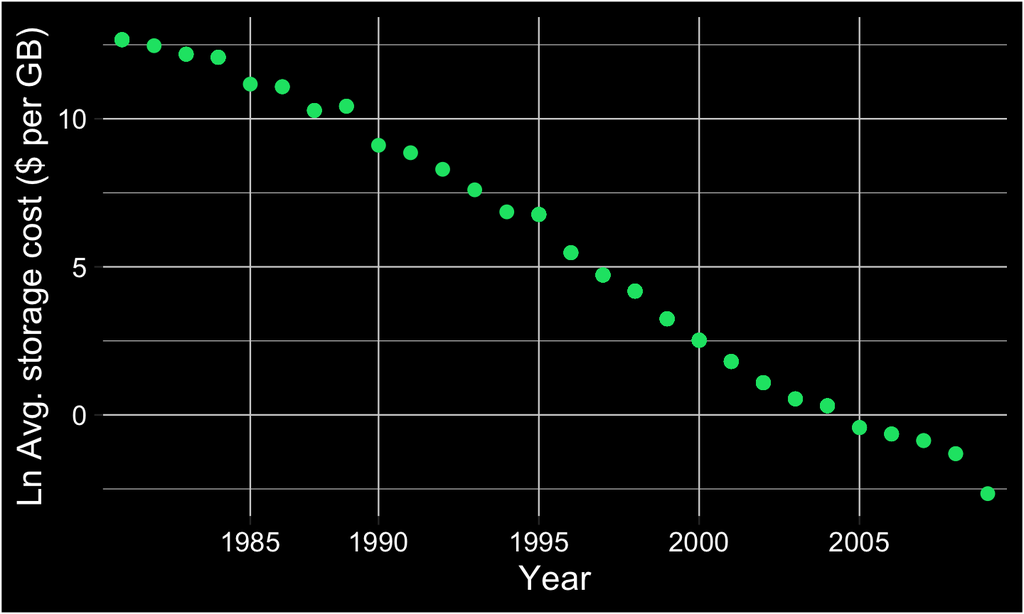

Data source: http://www.mkomo.com/cost-per-gigabyte

[figure not shown]

Source: https://techxerl.net.

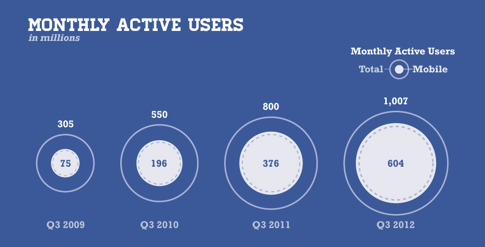

Source: statista.com.

[figure not shown]

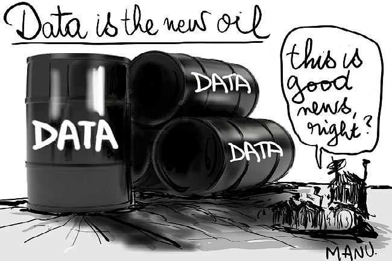

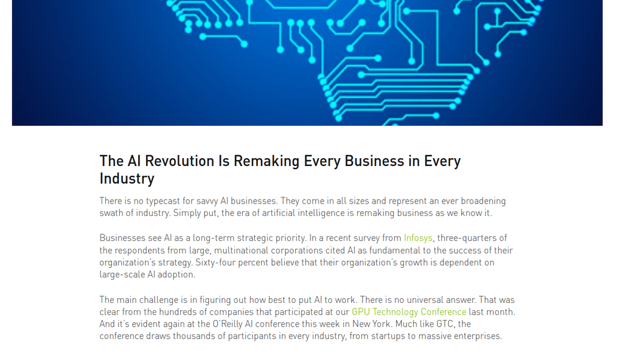

## Organization of the Course

## Our Team - At Your Service

| Philine Widmer | Ulrich Matter |
| --- | --- |

## Course Structure

## Course concept

- Lectures (Thursday morning)
  - Background/Concepts
  - Live demonstrations of concepts
  - Illustration of ‘hands-on’ approaches

## Course concept

- Lectures (Thursday morning)
  - Background/Concepts
  - Live demonstrations of concepts
  - Illustration of ‘hands-on’ approaches
- Workshops/Exercises (bi-weekly evening sessions)
  - Guided tutorials
  - Discussion of homework exercises
  - Recap of theoretical concepts

## Course concept

- Lectures (every Thursday morning)
  - Background/Concepts
  - Live demonstrations of concepts
  - Illustration of ‘hands-on’ approaches
- Workshops/Exercises (bi-weekly evening sessions)
  - Guided tutorials
  - Discussion of homework exercises
  - Recap of theoretical concepts
  - *First Exercises (set up R/RStudio) is available on StudyNet/Canvas today*

## Course concept

- Lectures (every Thursday morning)
  - Background/Concepts
  - Live demonstrations of concepts
  - Illustration of ‘hands-on’ approaches
- Workshops/Exercises (bi-weekly evening sessions)
  - Guided tutorials
  - Discussion of homework exercises
  - Recap of theoretical concepts
  - *First Exercises (set up R/RStudio) is available on StudyNet/Canvas today*
- Guest lecture and research insights

## Course concept

- Strongly encouraged: (virtual) learning groups!
  - Biweekly exercises provide opportunity.
  - Tackle the tricky exercises together!

## Part I: Data (Science) fundamentals

| Date | Topic |
| --- | --- |
| 17.09.20 | Introduction: Big Data/Data Science, course overview |
| 24.09.20 | An introduction to data and data processing |
| 24.09.20 | Exercises/Workshop 1: Tools, working with text files |
| 01.10.20 | Data storage and data structures |
| 08.10.20 | Research Insights |
| 08.10.20 | Exercises/Workshop 2: Computer code and data storage |
| 15.10.20 | Big Data from the Web |

## Part II: Data gathering and preparation

| Date | Topic |
| --- | --- |
| 22.10.20 | Programming with data |
| 22.10.20 | Exercises/Workshop 3: Programming with Data |
| 29.10.20 | Semester Break |
| 05.11.20 | Semester Break |
| 12.11.20 | Data sources, data gathering, data import |
| 19.11.20 | Data preparation and manipulation |
| 19.11.20 | Exercises/Workshop 4: Data import and data preparation/manipulation |

## Part III: Analysis, visualisation, output

| Date | Topic |
| --- | --- |
| 26.11.20 | Guest Lecture |
| 03.12.20 | Basic statistics and data analysis with R |
| 03.12.20 | Exercises/Workshop 5: Applied data analysis with R |
| 10.12.20 | Visualisation, dynamic documents |
| 17.12.20 | Summary, Wrap-Up, Q&A, Feedback |
| 17.12.20 | Exercises/Workshop 6: Visualization, dynamic documents |
| 18.12.20 | Exam for Exchange Students |

## Core course resources

- All information and materials (notes, slides, course sheet, syllabus, etc.) are available on StudyNet/Canvas.
- Exercises will be handed out via GitHub Classroom!
- Solutions to the exercises will be made available on Canvas.
- This course is *open souce*: all raw materials (code, source code for slides, notes, etc.) are freely available on [GitHub](https://github.com/umatter/datahandling)

## Main textbooks

[Murrell, Paul (2009). *Introduction to Data Technologies*, London: Chapman & Hall/CRC.](https://www.stat.auckland.ac.nz/~paul/ItDT/)

[Wickham, Hadley and Garred Grolemund (2017). *R for Data Science*, 1st Edition. Sebastopol, CA: O’Reilly.](http://r4ds.had.co.nz/)

## Further resources

- [Stackoverflow](https://stackoverflow.com/questions)
- [Get inspired in the R blogsphere](https://www.r-bloggers.com)

## Exam information

- Central, written examination.
- Multiple choice questions.
- A few open questions.
- Theoretical concepts and practical applications in R (questions based on code examples).

## Exam information II

- Exercises towards the end of the term will contain sample questions.
  - Get familiar with the style/format of questions.
- Exchange students who need to take the exam before the central exam block:
  - Questions: *philine.widmer@unisg.ch*!
  - Decentral exam for exchange students: *18 December 2020*.